# データ解析論II第5講

## 目次

## 前回の復習

## ロジスティック回帰分析

- 回帰分析と類似しているが「応答変数が2値」の時に利用する．
  - 説明変数は数値データでも因子データでも構わない．
- ロジスティック回帰分析は様々な応用がある．
  - 2値変数：二項ロジスティック回帰分析
  - 3項（カテゴリ）以上：多項ロジスティック回帰分析
  - 順序変数：順序ロジスティック回帰分析

## データ概要（教科書p.262）

```r
library(readr)
空き巣調査 <- read_csv("../data/空き巣調査.csv",
    locale = locale(encoding = "SHIFT-JIS"))
```

- 前回のデータの読み込み方を思い出しておきましょう．
- 「空き巣」：空き巣の被害の有無
- 「不在時間」：平日9時から18時の不在時間
- 「会話」：近隣住民との会話の回数
- 「築年数」：住居の築年数
- 「セキュリティ」：ホームセキュリティ会社のサービスへの加入・非加入
- 「飼い犬」：飼い犬の有無

## 回帰分析とロジスティック回帰分析の違い

- 回帰分析の目的：目的変数の値自体を予測・説明する
- ロジスティック回帰分析：2値カテゴリに分類される指標について，カテゴリAからカテゴリBとなる確率を説明する．
  - 基準カテゴリを設定して，もう一方にどのように変化するのかを明らかにする．
  - ダミー変数を作って，0が1に変化する確率を求める．

## より複雑なモデルへ

## 分析

- さらに，不在時間の影響について検討する．

```r
model2_logi <- glm(空き巣01 ~ 不在時間 + セキュリティ01,
                      family = "binomial", data=空き巣調査)
```

\[ \begin{aligned} \operatorname{空き巣01}_{\operatorname{1}} &\sim B\left(\operatorname{prob} = \hat{P},\operatorname{size} = 800\right) \\ \log\left[ \frac {\hat{P}}{1 - \hat{P}} \right] &= -1.53 + 0.41(\operatorname{不在時間}) \\ &- 0.53(\operatorname{セキュリティ01}) + \epsilon \end{aligned} \]

- セキュリティがあろうと無かろうと，不在時間が長いと空き巣に合う可能性が高まる．

## macの方はコチラを使ってください．

```r
graph2_mac<-空き巣調査 %>%
  ggplot( aes(x=不在時間, y=空き巣01), ) + geom_point() +
  stat_smooth(method="glm",
              method.args=list(family="binomial"),
              se=TRUE)+
  facet_grid(.~ セキュリティ01)+
  geom_jitter(height=0.01, width = 0.01)+
  theme_bw(base_family = "YuGo-Medium")
```

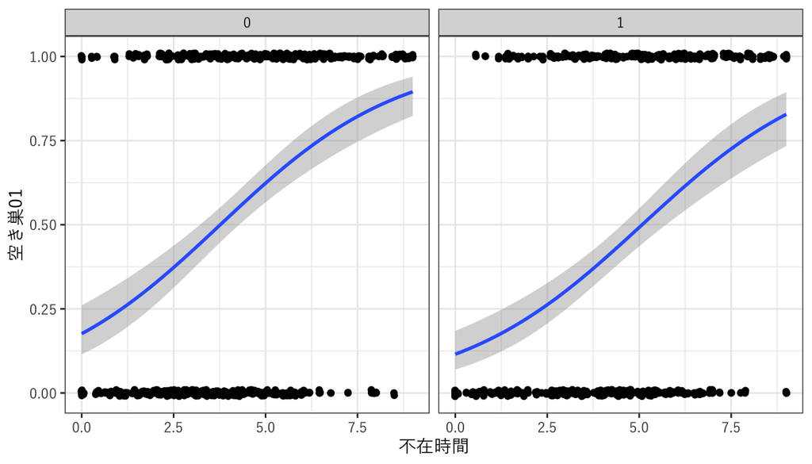

```r
graph2_mac
```

## モデル選択

- セキュリティだけのモデルと，不在時間の入ったモデルだと，どちらが妥当性が高いか検証しよう．

```r
anova(model1_logi, model2_logi, test = "Chisq")
```

```
## Analysis of Deviance Table
##
## Model 1: 空き巣01 ~ セキュリティ01
## Model 2: 空き巣01 ~ 不在時間 + セキュリティ01
##   Resid. Df Resid. Dev Df Deviance  Pr(>Chi)
## 1       798    1099.64
## 2       797     980.99  1   118.66 < 2.2e-16 ***
## ---
## Signif. codes:  0 '***' 0.001 '**' 0.01 '*' 0.05 '.' 0.1 ' ' 1
```

- 最後の`test = "Chisq"`は\(\chi^2\)分布を用いてモデルの妥当性を評価してほしいという指定をしている．
- この結果，不在時間の入ったモデルの方が妥当性が高いと考えられる．
- ただ，他にも変数があるので，全ての要因を入れてからモデル選択をしよう．

## 分析

- フルモデル（全ての変数が入ったモデル）．

```r
modelfull_logi <- glm(空き巣01 ~ 不在時間+ 会話 + 築年数
                         + セキュリティ01 + 飼い犬01,
                      family = "binomial", data=空き巣調査)
```

\[ \begin{aligned} \operatorname{空き巣01}_{\operatorname{1}} &\sim B\left(\operatorname{prob} = \hat{P},\operatorname{size} = 800\right) \\ \log\left[ \frac {\hat{P}}{1 - \hat{P}} \right] &= -0.94 + 0.39(\operatorname{不在時間}) - 0.55(\operatorname{会話}) \\ &+ 0.01(\operatorname{築年数}) - 0.55(\operatorname{セキュリティ01}) - 0.48(\operatorname{飼い犬01}) + \epsilon \end{aligned} \]

## 変数減少法

```r
modelstep<-step(modelfull_logi,direction = "backward")
```

```
## Start:  AIC=968.81
## 空き巣01 ~ 不在時間 + 会話 + 築年数 + セキュリティ01 +
##     飼い犬01
##
##                  Df Deviance     AIC
## - 築年数          1   957.11  967.11
## <none>                956.81  968.81
## - 飼い犬01        1   961.92  971.92
## - セキュリティ01  1   969.11  979.11
## - 会話            1   975.17  985.17
## - 不在時間        1  1062.33 1072.33
##
## Step:  AIC=967.11
## 空き巣01 ~ 不在時間 + 会話 + セキュリティ01 +
##     飼い犬01
##
##                  Df Deviance     AIC
## <none>                957.11  967.11
## - 飼い犬01        1   962.22  970.22
## - セキュリティ01  1   969.46  977.46
## - 会話            1   975.47  983.47
## - 不在時間        1  1062.46 1070.46
```

- AICが最良となったモデル \[ \begin{aligned} \operatorname{空き巣01}_{\operatorname{1}} &\sim B\left(\operatorname{prob} = \hat{P},\operatorname{size} = 800\right) \\ \log\left[ \frac {\hat{P}}{1 - \hat{P}} \right] &= -0.87 + 0.39(\operatorname{不在時間}) - 0.55(\operatorname{会話}) \\ &- 0.55(\operatorname{セキュリティ01}) - 0.48(\operatorname{飼い犬01}) + \epsilon \end{aligned} \]

## macの方はコチラを使ってください．

```r
graph3_mac<-空き巣調査 %>%
  ggplot(aes(x=不在時間, y=空き巣01,
             color=as.factor(会話), fill=as.factor(会話))) +
  geom_point(position=position_jitter(width=0.3,height=0.06),
             alpha=.4,shape=21,size=1.5) +
  stat_smooth(method="glm",
              method.args=list(family="binomial"),
              se=TRUE)+
  facet_grid(飼い犬01~ セキュリティ01)+
  geom_jitter(height=0.01, width = 0.01)+
  theme_bw(base_family = "YuGo-Medium")
```

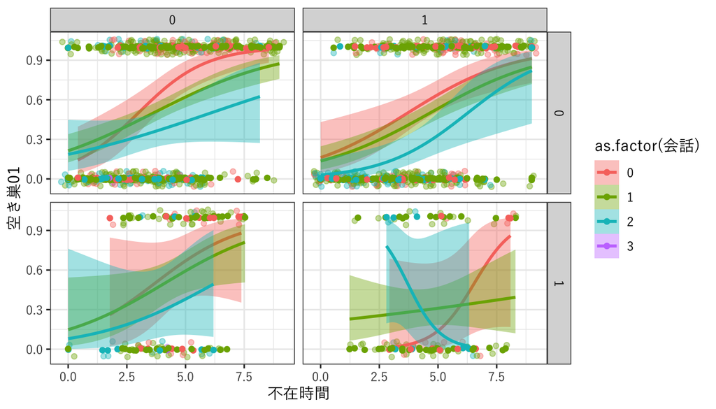

```r
graph3_mac
```

## ちなみに．．．．

```r
anova(modelfull_logi,　modelstep, test = "Chisq")
```

```
## Analysis of Deviance Table
##
## Model 1: 空き巣01 ~ 不在時間 + 会話 + 築年数 + セキュリティ01 +
##     飼い犬01
## Model 2: 空き巣01 ~ 不在時間 + 会話 + セキュリティ01 +
##     飼い犬01
##   Resid. Df Resid. Dev Df Deviance Pr(>Chi)
## 1       794     956.81
## 2       795     957.11 -1 -0.29394   0.5877
```

- anova()という関数で2つのモデルの妥当性を比較することができる．
  - 尤度比検定
  - 一般線形モデルの時と同様に評価できる．

## さらなる一般化線形モデルの説明

## ロジスティック回帰分析：

- 母集団の確率分布に2項分布を仮定する
- リンク関数にロジット関数を指定する．

## 2項分布

- 確率密度関数は以下の通りに示される．

\[_nC_k*p^k*(1-p)^{n-k}\]

- ただし，pを成功確率，nを試行回数，kを成功回数とする．
- また，\(_nC_k\)はコンビネーションと呼ばれ，n個の集団の中からk個を選ぶ場合の数を示す．

ex.売れる確率が0.2(=p)の商品が5つ(=n)あり，そのうち3つ(=k)が売れる確率は以下の通り．

\[_5C_3*p^3*(1-p)^{5-3}\]

すでに用意されている専用の関数もある．

```r
dbinom(3, size=5, prob=0.2)
```

```
## [1] 0.0512
```

## ロジスティック回帰分析とロジット関数

- ロジスティック回帰分析は試行回数nがわかっている状況で，成功確率pを求める．
  - pは確率であるために0-1の値しかとらない．

\[p=\frac{1}{1+exp\{-(ax+b)\}}\]

- exp(X)：eのX乗
- 線形予測子(ax+b)が小さくなる→分母が大きくなる→成功確率が0に近づく
- 線形予測子(ax+b)が大きくなる→分母が小さくなる→成功確率が1に近づく
- ロジット関数：ロジスティック関数の逆関数．両辺にロジット関数を適用すると，線形予測子が見やすくなる．

\[ln(\frac{p}{1-p}) = ax + b\]

- 引き続き，教科書p.273からはじまる「11.6モデルの意味」を精読しておいてください．

## オッズ

- 失敗するよりも何倍成功しやすいか
  - ex.オッズが2であれば失敗するよりも2倍成功しやすい．
- 成功確率をpとするとオッズは**\(\frac{p}{1-p}\)**
  - ex. p=1/2であれば，成功確率と失敗確率は等しくなる：オッズは\(\frac{1/2}{1-(1/2)}=\frac{1/2}{1/2}=1\)
  - ex. p=3/4であれば失敗確率は1/4となる：オッズは\(\frac{3/4}{1-(3/4)}=\frac{3/4}{1/4}=3\)
- 対数オッズ：オッズにログをとったもの **\(ln(\frac{p}{1-p}\))**
- 実際には対数オッズは解釈しにくいためにexpをとってオッズに戻してから解釈する．

## 分析結果

- 選ばれたモデルを評価しましょう

```
Coefficients:
               Estimate Std. Error z value Pr(>|z|)
(Intercept)    -0.86580    0.24118  -3.590 0.000331 ***
不在時間        0.39338    0.04186   9.398  < 2e-16 ***
会話           -0.54989    0.13063  -4.209 2.56e-05 ***
セキュリティ01 -0.54917    0.15745  -3.488 0.000487 ***
飼い犬01       -0.48100    0.21421  -2.245 0.024740 *
```

```r
exp(modelstep$coefficients)
```

```
##    (Intercept)       不在時間           会話 セキュリティ01       飼い犬01
##      0.4207135      1.4819782      0.5770136      0.5774281      0.6181666
```

- 教科書p.273での報告例では「築年数」も入っているフルモデルが掲載されています．
- 今回はモデル選択をしたので築年数を除いたモデルを採択しているが，フルモデルと築年数を除いたモデルのいずれを報告しても構わない．
  - 実際には，フルモデルとモデル選択をしたこのモデルを並列して記述することになる．

## 確率分布を学ぼう

- [様々な確率分布の例](https://paiza.hatenablog.com/entry/probability_distributions)
- [実際にプロットしてみるサービス](https://statdist.ksmzn.com/)

## 因子分析

## 因子分析とは

\(観測変数 = 共通因子 + 独自因子\)

- ある観測された変数が，どのような潜在的な変数の影響を受けているのか分析する手法
  - 心理学分野だと「構成概念」として議論されている．
- 観測変数：実際に観測された変数
  - ex.国語の点数，数学の点数，社会の点数，理科の点数etc.
- 共通因子：複数の要因に共通する特徴
  - 国語と社会には「文系能力」という潜在変数が共通因子として存在する．
  - 数学と理科には「理系能力」という潜在変数が共通因子として存在する．
- 独自因子：各項目における固有の要因
  - 国語独自の問題，数学独自の問題，社会独自の問題，理科独自の問題，
  - 独自因子は「誤差」として扱う

\(観測変数 = 共通因子 + e_i\)

## 2種類の因子分析

- 探索的因子分析：どのような因子存在して影響を与えているのか，よくわからない場合などに用いる．
  - ex.新しい質問紙を開発する時に用いる
- 確証的因子分析：先行研究や仮説にあわせて因子構造を確認する
  - ex.既に先行研究で検証されている質問紙を使う時に用いる．

## 探索的因子分析の手続き

- 因子分析を行う意義の確認
  - Kaiser-Meyer-Olkinの標本妥当性の測度（KMO 測度）：データに少なくとも１つの潜在因子が存在しそうかどうかを検証する．
  - これは行う時と行わない時があるが，最近はやりがち．
- 因子数の決定
  - ガットマン基準：観測変数の相関行列の固有値をもとに因子数を決定する，値が1.0以上のものを採用
  - スクリープロット：固有値を縦軸，因子の番号を横軸として，固有値の変化をプロットしたグラフ．固有値の値がなだらかになる直前までの固有値の数を因子数とする．
  - 平行分析：変数の標本サイズが実際のデータと同一の乱数データを作成して，そこから固有値平均をもとめて比較する．
- 因子負荷の推定
  - 観測変数が書く因子をどの程度反映しているかが示される．
  - 探索的因子分析では，因子不可は各観測変数につき，因子の数だけ推定される．
    - 重回帰分析でフルモデルから考えているようなもの
  - 各因子がどのような構成概念を反映したものであるかは，推定された因子負荷の値を見て判断する．
- 因子数が複数の時は因子軸の回転
  - 因子が単純構造であるほうが解釈がしやすいため，単純構造になるようにする．
    - 単純構造：各観測変数が1つの因子だけから高い因子負荷を受け，他の因子からの因子負荷が0に近い状況
  - 単純構造に成るように因子軸の回転を行う．
    - PROMAX回転がよく使われる．
- 因子の解釈
  - 各因子を強く反映する変数の内容から，その因子の内容を推測すること．
    - 各因子がどのような概念を示しているかについて，因子名をつける．

## 今日扱うデータの概要

- 今回扱うデータ：クラウドソーシングを用いた意思決定に関するデータの一部
  - 現在分析中のデータなので，あまり外部に流出しないように気をつけてください．

**[データ](https://www.dropbox.com/sh/ld9wqf25rjl3ege/AAD667w9lS2j12yX_32V5xhya?dl=0)**

この中から，ratemo_1からratemo_24までのデータを分析する．

- REI日本語版：情報処理スタイル尺度，直観的処理と合理的処理における個人差を明らかにする尺度（内藤et.al, 2004）
  - Epstein et. al（1996）のREI(Rational Experiential Inventory)の日本語版
- 短縮版を採用
- 直観・感情的な反応を示すシステム1と論理・理性的な思考をもたらすシステム2を反映
  - Kahneman, 2012; Evans, 2010
- **[参考資料①](https://www.jstage.jst.go.jp/article/personality/13/1/13_1_67/_pdf/-char/ja)**

| 逆転項目 | 短縮版 | 順番 | 項目 |
| --- | --- | --- | --- |
|  | ＊ | 1 | たいていの人より，ものごとを論理的に解決するのが上手である． |
| ＊ | ＊ | 2 | 直観に頼らなければならない状況は好きではない． |
|  | ＊ | 3 | 自分の予感を信じることにしている． |
|  | ＊ | 4 | 論理的な考えの持ち主だ． |
| ＊ | ＊ | 5 | ものごとを注意深く理論的に解決するのは，得意ではない． |
|  | ＊ | 6 | 簡単な問題より複雑な問題の方が好きだ． |
|  | ＊ | 7 | なぜだか理由を説明できないが，その人が正しいか間違っているかを，感じとることができる． |

| 逆転項目 | 短縮版 | 順番 | 項目 |
| --- | --- | --- | --- |
| ＊ | ＊ | 8 | 分析的に考える方ではない． |
| ＊ | ＊ | 9 | 私にはすごい直観力はない． |
| ＊ | ＊ | 10 | 考えることは，楽しいことだと思わない． |
|  | ＊ | 11 | 直観は問題を解決するのに役立つ方法だろう． |
| ＊ | ＊ | 12 | 感情に基づいて重要な決定をするのは，愚かなことだと思う． |
|  | ＊ | 13 | 行動を決める時，直観に頼ることが多い． |
|  | ＊ | 14 | 私にとって，新しい考え方を学ぶことは，とても魅力的である． |

| 逆転項目 | 短縮版 | 順番 | 項目 |
| --- | --- | --- | --- |
| ＊ | ＊ | 15 | 複雑な問題を解決するのは，得意ではない． |
|  | ＊ | 16 | 知的な挑戦が好きだ． |
| ＊ | ＊ | 17 | 直観に頼って重要な決定をするのは，いい考えだと思わない． |
| ＊ | ＊ | 18 | もし私が直観に頼るならば，間違いをおかすことが多くなるだろう． |
|  | ＊ | 19 | 直観的な印象に頼るのが好きだ． |
|  | ＊ | 20 | 一生懸命考えなければならないような問題を解決するのが好きだ． |

| 逆転項目 | 短縮版 | 順番 | 項目 |
| --- | --- | --- | --- |
|  | ＊ | 21 | 答えを見つけるために直観に従って，うまくいかなかったことはほとんどない． |
|  | ＊ | 22 | 人生や生活上のいろんな問題を考えるとき，直観的にやるとうまくいく． |
| ＊ | ＊ | 23 | 注意深く論理的な分析が必要とされる問題を解決するのは，得意ではない． |
| ＊ | ＊ | 24 | いろいろ考えるのは好きではない． |

## 逆転項目とは

- 逆転項目：他の質問項目とは違い，測定の向きが逆であるデータ．
  - 因子分析を行う際には，逆転項目は反転させる必要がある．
- 今回の調査では：
  - 「1 ：全くあてはまらない」「2 ：あまりあてはまらない」「3 ：どちらともいえない」「4 ：少しあてはまる」「5 ：非常にあてはまる」
  - 逆転項目については1→5，2→4，3→3，4→2，5→1に置き換える必要がある．
  - 該当項目については6からそれぞれの値を引いてあげれば良い．

## 逆転項目に対応しよう

```r
library(readr)
factanal <- read_csv("../data/factanal.csv")

library(dplyr)
factanal <- mutate(factanal, gyaku_ratemo_2=6-ratemo_2)
factanal <- mutate(factanal, gyaku_ratemo_5=6-ratemo_5)
factanal <- mutate(factanal, gyaku_ratemo_8=6-ratemo_8)
factanal <- mutate(factanal, gyaku_ratemo_9=6-ratemo_9)
factanal <- mutate(factanal, gyaku_ratemo_10=6-ratemo_10)
factanal <- mutate(factanal, gyaku_ratemo_12=6-ratemo_12)
factanal <- mutate(factanal, gyaku_ratemo_15=6-ratemo_15)
factanal <- mutate(factanal, gyaku_ratemo_17=6-ratemo_17)
factanal <- mutate(factanal, gyaku_ratemo_18=6-ratemo_18)
factanal <- mutate(factanal, gyaku_ratemo_23=6-ratemo_23)
factanal <- mutate(factanal, gyaku_ratemo_24=6-ratemo_24)
```

## 分析の準備

```r
#install.packages( "psych" )
#install.packages( "GPArotation" )

library( psych )
library( GPArotation )
```

- この2つのパッケージを用います．必要に応じてインストールをしてください．

## 新たなデータセットの作成

- 必要なデータだけを取り出します．

```r
library(dplyr)
REI <- factanal %>%
  select(c(ratemo_1,gyaku_ratemo_2,ratemo_3,ratemo_4,
           gyaku_ratemo_5,ratemo_6,ratemo_7,gyaku_ratemo_8,
           gyaku_ratemo_9,gyaku_ratemo_10,ratemo_11,
           gyaku_ratemo_12,ratemo_13,ratemo_14,
           gyaku_ratemo_15,ratemo_16,gyaku_ratemo_17,
           gyaku_ratemo_18,ratemo_19,ratemo_20,
           ratemo_21,ratemo_22,gyaku_ratemo_23,
           gyaku_ratemo_24))
```

## 分析の前のデータチェック

- Kaiser-Meyer-Olkinの標本妥当性の測度（KMO 測度）でデータに少なくとも１つの潜在因子が存在しそうかを調べます．
  - Overall MSAが0.6以上であることが望ましい．

```r
KMO(REI)
```

```
## Kaiser-Meyer-Olkin factor adequacy
## Call: KMO(r = REI)
## Overall MSA =  0.9
## MSA for each item =
##        ratemo_1  gyaku_ratemo_2        ratemo_3        ratemo_4  gyaku_ratemo_5
##            0.88            0.90            0.90            0.87            0.90
##        ratemo_6        ratemo_7  gyaku_ratemo_8  gyaku_ratemo_9 gyaku_ratemo_10
##            0.92            0.86            0.92            0.90            0.91
##       ratemo_11 gyaku_ratemo_12       ratemo_13       ratemo_14 gyaku_ratemo_15
##            0.92            0.85            0.91            0.90            0.92
##       ratemo_16 gyaku_ratemo_17 gyaku_ratemo_18       ratemo_19       ratemo_20
##            0.92            0.87            0.89            0.91            0.91
##       ratemo_21       ratemo_22 gyaku_ratemo_23 gyaku_ratemo_24
##            0.91            0.91            0.93            0.92
```

## スクリープロットの作成：

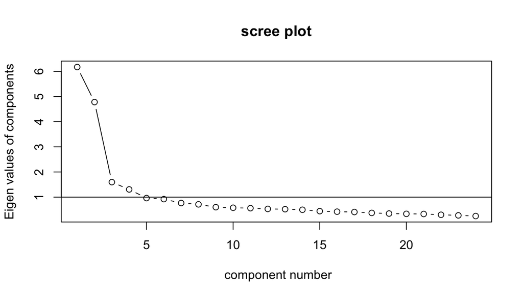

```r
correlation = cor(REI) # 相関行列の計算
VSS.scree(REI) # スクリープロットの表示
```

- Screeplot：ある成分や因子に対して，それに対応する固有値を降順でプロットしたグラフのこと． 因子や成分の寄与の大きさの指標となる．
  - 固有値がガクッと曲がっているところが因子数の基準．
  - 固有値：分散の大きさの基準．因子が増えると分散を小さくできるけど，たくさんあるとめんどいから，程々のところで考えよう．

## 平行分析：

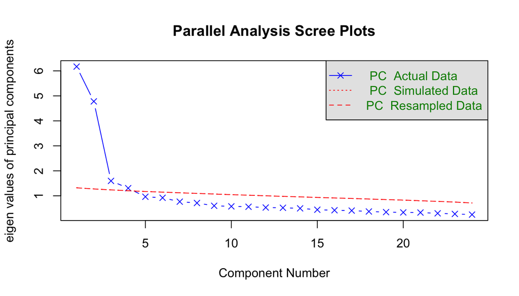

```
## Parallel analysis suggests that the number of factors =  NA  and the number of components =  4
```

```r
fa.parallel(REI, fa = "pc" , n.iter = 100)
```

- 平行分析：変数の数と標本サイズが実際のデータと同じ乱数データをn個作成して，n個の乱数データそれぞれで固有値を算出し，n個の固有値の平均を算出します．

## MAP基準とBIC基準：

- 因子数決定の統計的な基準として，MAP基準およびBIC基準があります．

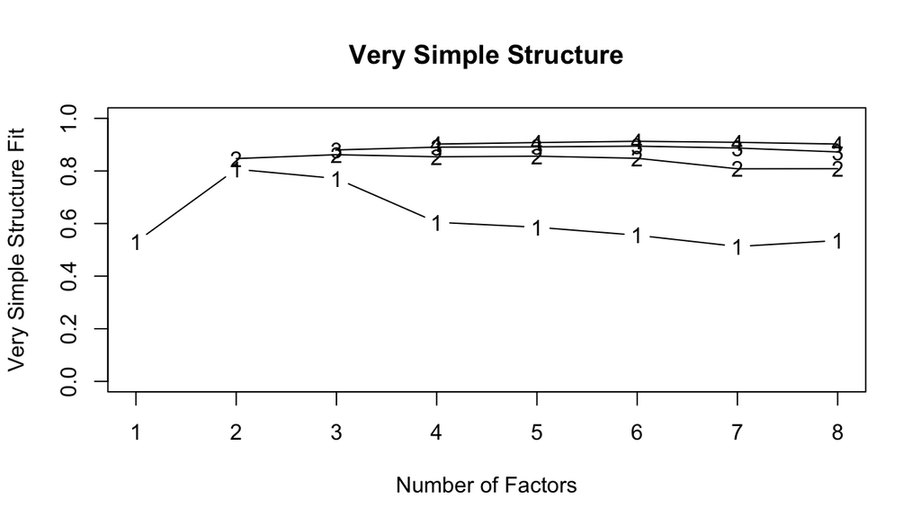

```
##
## Very Simple Structure
## Call: vss(x = x, n = n, rotate = rotate, diagonal = diagonal, fm = fm,
##     n.obs = n.obs, plot = plot, title = title, use = use, cor = cor)
## VSS complexity 1 achieves a maximimum of 0.81  with  2  factors
## VSS complexity 2 achieves a maximimum of 0.86  with  3  factors
##
## The Velicer MAP achieves a minimum of 0.01  with  4  factors
## BIC achieves a minimum of  -670.5  with  6  factors
## Sample Size adjusted BIC achieves a minimum of  -206.51  with  7  factors
##
## Statistics by number of factors
##   vss1 vss2   map dof chisq     prob sqresid  fit RMSEA  BIC SABIC complex
## 1 0.53 0.00 0.048 252  4640  0.0e+00    33.4 0.53 0.148 2958  3758     1.0
## 2 0.81 0.85 0.018 229  1925 2.2e-265    10.9 0.85 0.097  396  1123     1.1
## 3 0.77 0.86 0.016 207  1246 7.5e-148     8.5 0.88 0.080 -136   522     1.3
## 4 0.60 0.85 0.014 186   704  3.1e-61     7.0 0.90 0.059 -538    52     1.6
## 5 0.59 0.86 0.016 166   515  2.5e-37     6.2 0.91 0.051 -594   -67     1.7
## 6 0.56 0.85 0.019 147   311  8.2e-14     5.6 0.92 0.037 -671  -204     1.9
## 7 0.51 0.81 0.022 129   245  3.1e-09     5.2 0.93 0.034 -616  -207     2.0
## 8 0.54 0.81 0.027 112   198  9.6e-07     4.8 0.93 0.031 -550  -194     2.2
##   eChisq  SRMR eCRMS  eBIC
## 1  14502 0.182 0.190 12819
## 2   1755 0.063 0.069   226
## 3    918 0.046 0.053  -464
## 4    415 0.031 0.037  -827
## 5    274 0.025 0.032  -834
## 6    140 0.018 0.025  -841
## 7     99 0.015 0.022  -762
## 8     70 0.013 0.020  -678
```

```r
VSS(REI) # MAP基準およびBIC基準による因子数の検証
```

## 因子負荷の推定：

```r
fa_REI <- fa(REI, nfactors = 2, fm = "ml", rotate = "none")
fa_REI
```

```
## Factor Analysis using method =  ml
## Call: fa(r = REI, nfactors = 2, rotate = "none", fm = "ml")
## Standardized loadings (pattern matrix) based upon correlation matrix
##                   ML1   ML2   h2   u2 com
## ratemo_1         0.66 -0.11 0.45 0.55 1.1
## gyaku_ratemo_2   0.10  0.54 0.30 0.70 1.1
## ratemo_3         0.21  0.54 0.33 0.67 1.3
## ratemo_4         0.65 -0.21 0.47 0.53 1.2
## gyaku_ratemo_5   0.65 -0.10 0.43 0.57 1.1
## ratemo_6         0.66 -0.10 0.44 0.56 1.0
## ratemo_7         0.25  0.36 0.19 0.81 1.8
## gyaku_ratemo_8   0.60 -0.22 0.41 0.59 1.3
## gyaku_ratemo_9   0.31  0.52 0.36 0.64 1.6
## gyaku_ratemo_10  0.62 -0.07 0.39 0.61 1.0
## ratemo_11        0.13  0.61 0.39 0.61 1.1
## gyaku_ratemo_12  0.02  0.48 0.23 0.77 1.0
## ratemo_13       -0.12  0.66 0.44 0.56 1.1
## ratemo_14        0.47  0.03 0.22 0.78 1.0
## gyaku_ratemo_15  0.74 -0.01 0.54 0.46 1.0
## ratemo_16        0.73 -0.08 0.54 0.46 1.0
## gyaku_ratemo_17  0.11  0.67 0.46 0.54 1.1
## gyaku_ratemo_18  0.23  0.60 0.41 0.59 1.3
## ratemo_19        0.02  0.75 0.56 0.44 1.0
## ratemo_20        0.70 -0.03 0.49 0.51 1.0
## ratemo_21        0.10  0.43 0.20 0.80 1.1
## ratemo_22        0.18  0.69 0.51 0.49 1.1
## gyaku_ratemo_23  0.74 -0.09 0.56 0.44 1.0
## gyaku_ratemo_24  0.68 -0.07 0.46 0.54 1.0
##
##                        ML1  ML2
## SS loadings           5.62 4.20
## Proportion Var        0.23 0.17
## Cumulative Var        0.23 0.41
## Proportion Explained  0.57 0.43
## Cumulative Proportion 0.57 1.00
##
## Mean item complexity =  1.1
## Test of the hypothesis that 2 factors are sufficient.
##
## The degrees of freedom for the null model are  276  and the objective function was  10.9 with Chi Square of  8548.38
## The degrees of freedom for the model are 229  and the objective function was  2.46
##
## The root mean square of the residuals (RMSR) is  0.06
## The df corrected root mean square of the residuals is  0.07
##
## The harmonic number of observations is  794 with the empirical chi square  1761.2  with prob <  3e-234
## The total number of observations was  794  with Likelihood Chi Square =  1923.04  with prob <  4.6e-265
##
## Tucker Lewis Index of factoring reliability =  0.753
## RMSEA index =  0.097  and the 90 % confidence intervals are  0.093 0.101
## BIC =  393.99
## Fit based upon off diagonal values = 0.95
## Measures of factor score adequacy
##                                                    ML1  ML2
## Correlation of (regression) scores with factors   0.96 0.94
## Multiple R square of scores with factors          0.91 0.88
## Minimum correlation of possible factor scores     0.83 0.76
```

## 因子負荷の推定：

```r
fa_REI2 <- fa(REI, nfactors = 2, fm = "ml", rotate = "promax")
fa_REI2
```

```
## Factor Analysis using method =  ml
## Call: fa(r = REI, nfactors = 2, rotate = "promax", fm = "ml")
## Standardized loadings (pattern matrix) based upon correlation matrix
##                   ML1   ML2   h2   u2 com
## ratemo_1         0.68 -0.03 0.45 0.55 1.0
## gyaku_ratemo_2  -0.03  0.55 0.30 0.70 1.0
## ratemo_3         0.08  0.56 0.33 0.67 1.0
## ratemo_4         0.69 -0.13 0.47 0.53 1.1
## gyaku_ratemo_5   0.66 -0.02 0.43 0.57 1.0
## ratemo_6         0.66 -0.01 0.44 0.56 1.0
## ratemo_7         0.17  0.39 0.19 0.81 1.4
## gyaku_ratemo_8   0.64 -0.14 0.41 0.59 1.1
## gyaku_ratemo_9   0.19  0.56 0.36 0.64 1.2
## gyaku_ratemo_10  0.63  0.01 0.39 0.61 1.0
## ratemo_11       -0.01  0.63 0.39 0.61 1.0
## gyaku_ratemo_12 -0.08  0.48 0.23 0.77 1.1
## ratemo_13       -0.26  0.64 0.44 0.56 1.3
## ratemo_14        0.45  0.09 0.22 0.78 1.1
## gyaku_ratemo_15  0.72  0.09 0.54 0.46 1.0
## ratemo_16        0.73  0.01 0.54 0.46 1.0
## gyaku_ratemo_17 -0.05  0.68 0.46 0.54 1.0
## gyaku_ratemo_18  0.09  0.63 0.41 0.59 1.0
## ratemo_19       -0.15  0.75 0.56 0.44 1.1
## ratemo_20        0.70  0.05 0.49 0.51 1.0
## ratemo_21        0.00  0.45 0.20 0.80 1.0
## ratemo_22        0.02  0.71 0.51 0.49 1.0
## gyaku_ratemo_23  0.75  0.00 0.56 0.44 1.0
## gyaku_ratemo_24  0.68  0.01 0.46 0.54 1.0
##
##                        ML1  ML2
## SS loadings           5.53 4.28
## Proportion Var        0.23 0.18
## Cumulative Var        0.23 0.41
## Proportion Explained  0.56 0.44
## Cumulative Proportion 0.56 1.00
##
##  With factor correlations of
##     ML1 ML2
## ML1 1.0 0.1
## ML2 0.1 1.0
##
## Mean item complexity =  1.1
## Test of the hypothesis that 2 factors are sufficient.
##
## The degrees of freedom for the null model are  276  and the objective function was  10.9 with Chi Square of  8548.38
## The degrees of freedom for the model are 229  and the objective function was  2.46
##
## The root mean square of the residuals (RMSR) is  0.06
## The df corrected root mean square of the residuals is  0.07
##
## The harmonic number of observations is  794 with the empirical chi square  1761.2  with prob <  3e-234
## The total number of observations was  794  with Likelihood Chi Square =  1923.04  with prob <  4.6e-265
##
## Tucker Lewis Index of factoring reliability =  0.753
## RMSEA index =  0.097  and the 90 % confidence intervals are  0.093 0.101
## BIC =  393.99
## Fit based upon off diagonal values = 0.95
## Measures of factor score adequacy
##                                                    ML1  ML2
## Correlation of (regression) scores with factors   0.96 0.94
## Multiple R square of scores with factors          0.91 0.88
## Minimum correlation of possible factor scores     0.83 0.76
```

- ML1：因子1の負荷
- ML2：因子2の負荷
- h2：共通性

## 因子数を確認したあと．．

- 因子分析にはいくつかのスタンスがある．
  - 探索的因子分析：どのような因子存在して影響を与えているのか，よくわからない場合などに用いる．
    - ex.新しい質問紙を使う時に用いる
  - 確証的因子分析：先行研究や仮説にあわせて因子数を確認する
    - ex.先行研究で知見が確立しているので，今回は確証的因子分析をもとにしてよい

## 演習問題：

- 教科書p.162から説明されている方法について確認しておきましょう．
  - 必ずしも全てのコードを動かす必要がないが，理解を深めるためには手を動かすことが必要です．